# Investigating Economies of Scale in California Banks

Author

Tyler Kao

## Introduction

In modern media, there is a widespread idea of being too big to fail. Firms such as JPMC, Bank of America, Citigroup, Wells Fargo, Goldman Sachs, Morgan Stanley, BNY Mellon, and State Street are designated with this label by the Financial Stability Board. In this paper, I wanted to investigate if California banks specifically follow the idea of Economies of Scale, where a bank becomes more efficient the larger it gets in total size (measured in assets), or if there is an optimal range for banks to stay in.

## Modeling Background

To look at this idea in depth, I used two different modeling styles. Linear regression and log-log regression to evaluate net income vs total assets, alongside earning assets vs total deposits, respectively. A log-log regression was used in model two, as measuring the total percent growth based on size would be greatly skewed due to the presence of larger banks in the dataset compared to the higher volume of smaller banks.

## Data Cleaning

**View the R Code**

```r
bank_data <- read.csv(
  "/Users/tylerkao/Desktop/Econ Modeling Data /FDIC_Bank_Final.csv",
  header = TRUE,
  stringsAsFactors = FALSE,
  fill = TRUE)

ca_banks <- subset(bank_data, STALP == "CA")

ca_banks_active <- subset(ca_banks,
                          OALIFGEN > 0 &
                          ASSET2 > 0 &
                          NETINC > 0 &
                          DEP > 0
                          )
```

## Graph One

Looking at the summary statistics, a $1 increase in total assets leads to a $0.006689 increase in net income, which is approximately 0.67 of a cent per $1. The high R-Squared value indicates that 93.23% of the variance in a bank’s net income can be explained by its total assets. Based on this data, we can conclude that a bank’s size acts as a primary reason for its profitability. Based on the R-Squared value, and no drop off in the data, we can assume that economies of scale are present as banks increase in size while continuing to be profitable.

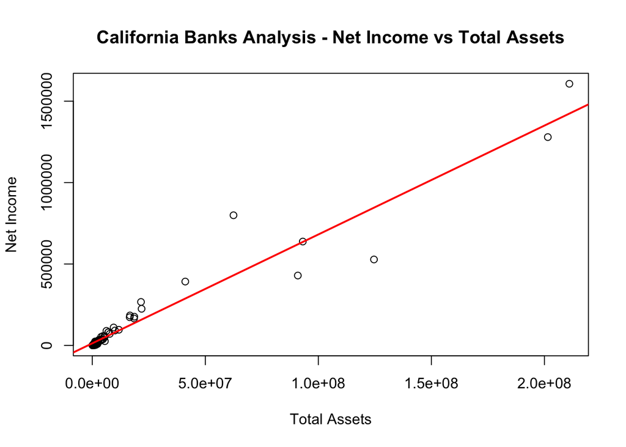

```
Call:
lm(formula = NETINC ~ ASSET2, data = ca_banks_active)

Residuals:
    Min      1Q  Median      3Q     Max
-318393  -12504   -9120    2300  368819

Coefficients:
             Estimate Std. Error t value Pr(>|t|)
(Intercept) 1.262e+04  7.903e+03   1.597    0.114
ASSET2      6.689e-03  2.014e-04  33.205   <2e-16 ***
---
Signif. codes:  0 '***' 0.001 '**' 0.01 '*' 0.05 '.' 0.1 ' ' 1

Residual standard error: 67220 on 80 degrees of freedom
Multiple R-squared:  0.9323,    Adjusted R-squared:  0.9315
F-statistic:  1103 on 1 and 80 DF,  p-value: < 2.2e-16
```

## Graph Two

Based on the summary statistics, a 1% increase in total deposits leads to a 1.004065% increase in earning assets, which is approximately a 1.004% growth of earning assets. The high R-Squared value indicates that 99.77% of the variance in a bank’s earning assets can be explained by its total deposits. Based on the percentage relationship between earning assets and total deposits, we can see that the value of 1.004% indicates that there are increasing returns to scale. As a smaller bank grows in size, it gains a small bit of the marginal benefits from said growth.

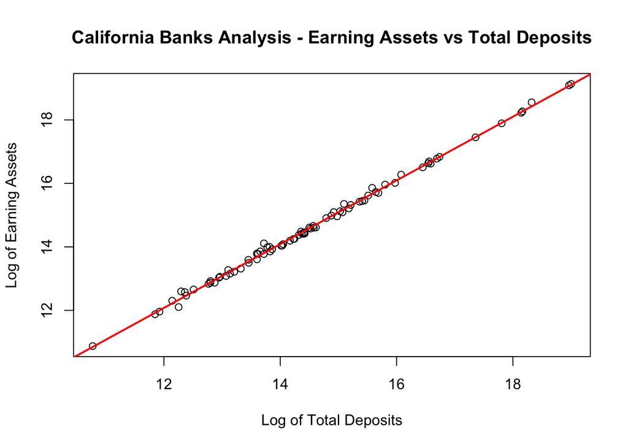

```
Call:
lm(formula = log(ERNAST) ~ log(DEP), data = ca_banks_active)

Residuals:
     Min       1Q   Median       3Q      Max
-0.22675 -0.05999 -0.01158  0.03396  0.30670

Coefficients:
            Estimate Std. Error t value Pr(>|t|)
(Intercept)  0.02836    0.07966   0.356    0.723
log(DEP)     1.00406    0.00544 184.571   <2e-16 ***
---
Signif. codes:  0 '***' 0.001 '**' 0.01 '*' 0.05 '.' 0.1 ' ' 1

Residual standard error: 0.08316 on 80 degrees of freedom
Multiple R-squared:  0.9977,    Adjusted R-squared:  0.9976
F-statistic: 3.407e+04 on 1 and 80 DF,  p-value: < 2.2e-16
```

## Conclusion

Based on the data presented in the previous graphs, we can conclude that economies of scale are a industry wide characteristic in California based banks. In the linear regression model comparing net income and total assets, we can see that as banks increase in size, there is a consistent gain in profits, disproving the notion of increased firm size leading to decreases in efficiency. The high R-Squared value of approximately 93% shows a strong correlation between the net income and assets, showing that income continues to increase even at scale. In graph two, we observe a 1.004% increase in earning assets per 1% increase in deposits. This shows how larger banks can become more efficient than smaller firms due to the returns at scale. Both graphs support the idea that economies of scale are a industry wide characteristic in California banks, as growth in total size (assets) leads to increases in total profit and efficiency.